# Traffic and Drugs Related Violations Dataset

### - How many Arrested vs Not Arrested

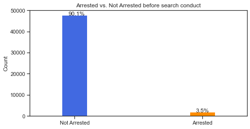

```python
# how many Arrested vs Not Arrested

def visualize_target(df):
    fig, ax = plt.subplots()
    fig.canvas.draw()
    df.is_arrested.value_counts().plot(kind="bar", width=0.2, figsize=(8, 4), color = ["royalblue","darkorange"])
    plt.ylabel("Count", fontsize=12)
    plt.title("Arrested vs. Not Arrested before search conduct")
    for i in ax.patches:
        percentage = '{:.1f}%'.format(100 * i.get_height()/len(df.is_arrested))
        x = i.get_x() + i.get_width() - 0.15
        y = i.get_height()
        ax.annotate(percentage, (x, y))
    ax.set_xticklabels(["Not Arrested", "Arrested"], rotation = 0);

visualize_target(traffic_df)
```

```python
traffic_df.groupby('is_arrested').count()
```

| is_arrested | stop_date | stop_time | country_name | driver_gender | driver_age_raw | driver_age | driver_race | violation_raw | violation | search_conducted | search_type | stop_outcome | stop_duration | drugs_related_stop |
| --- | --- | --- | --- | --- | --- | --- | --- | --- | --- | --- | --- | --- | --- | --- |
| False | 47712 | 47712 | 0 | 47711 | 47712 | 47473 | 47712 | 47712 | 47712 | 47712 | 1246 | 47712 | 47712 | 47712 |
| True | 1869 | 1869 | 0 | 1869 | 1869 | 1868 | 1869 | 1869 | 1869 | 1869 | 839 | 1869 | 1869 | 1869 |

# Data Preparation and Preprocessing

### - Check the row duplication

```python
print('Use the keep parameter to consider only the first instance of a duplicate row to be unique: \n')
bool_series = traffic_df.duplicated(keep='first')
print('Boolean series:')
print(set(bool_series))
print('\n')


traffic_df = traffic_df[~bool_series]
```

```
Use the keep parameter to consider only the first instance of a duplicate row to be unique:

Boolean series:
{False, True}
```

```python
print('Recheck  the row duplication: ')
bool_series = traffic_df.duplicated(keep='first')

print('Are there any duplication: ', set(bool_series))
```

```
Recheck  the row duplication:
Are there any duplication:  {False}
```

### - Remove columns that more 90% of their rows is nulls or it's a raw data

```python
print('Check the nulls values in each columns and delete the columns with more thab 90% of it is null: \n')
for column in traffic_df.columns:
    prec = traffic_df[column].isna().sum()/len(traffic_df) * 100

    if prec > 90 or column in ['driver_age_raw','violation_raw']:
        traffic_df.drop(column, axis=1, inplace=True)
```

```
Check the nulls values in each columns and delete the columns with more thab 90% of it is null:
```

```python
print('check the total null values: \n', traffic_df.isna().sum())
```

```
check the total null values:
 stop_date                0
stop_time                1
driver_gender         3269
driver_age            3503
driver_race           3268
violation             3268
search_conducted         1
stop_outcome          3268
is_arrested           3268
stop_duration         3268
drugs_related_stop       1
dtype: int64
```

### - Fill the null based on the statistical measured

```python
print('If the column type is categorical and contains only 1 missing, \n fill it with the mode ')
for column in traffic_df.columns:

    if traffic_df[column].isna().sum() == 1 and traffic_df.dtypes[column] == np.object:
        traffic_df[column] = traffic_df[column].fillna(traffic_df[column].mode()[0])
```

```
If the column type is categorical and contains only 1 missing,
 fill it with the mode
```

```python
print('check the total null values: \n', traffic_df.isna().sum())
```

```
check the total null values:
 stop_date                0
stop_time                0
driver_gender         3269
driver_age            3503
driver_race           3268
violation             3268
search_conducted         0
stop_outcome          3268
is_arrested           3268
stop_duration         3268
drugs_related_stop       0
dtype: int64
```

```python
# Let check pre column how many is Arrested vs. Not Arrested

print('Check how many Arrested and Not Arrested is missing in each column: \n')

nan_columns = ['driver_gender', 'driver_race' , 'violation' , 'stop_outcome', 'is_arrested', 'stop_duration']

for column  in nan_columns:
    list_index = traffic_df[traffic_df[column].isnull()].index.tolist()
    num_of_items = len(traffic_df.loc[list_index].groupby('is_arrested'))
    print(column, " null items pre is_arrested type ", str(num_of_items))
```

```
Check how many Arrested and Not Arrested is missing in each column:

driver_gender  null items pre is_arrested type  1
driver_race  null items pre is_arrested type  0
violation  null items pre is_arrested type  0
stop_outcome  null items pre is_arrested type  0
is_arrested  null items pre is_arrested type  0
stop_duration  null items pre is_arrested type  0
```

```
Based on the previous information we are save to delete the empty rows:
```

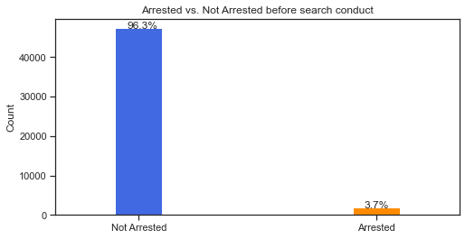

```python
print('Based on the previous information we are save to delete the empty rows: \n')
traffic_df.dropna(how='any', inplace=True)

# visualize target
visualize_target(traffic_df)
```

### - Encode the categorical data

To use SVM or logistic regression, we need to have numeric values. Encode the categorical columns.

```python
# split the dates to year, months and day


traffic_df['stop_year'] = traffic_df['stop_date'].apply(lambda x: int(x.split('/')[2]))
traffic_df['stop_month'] = traffic_df['stop_date'].apply(lambda x: int(x.split('/')[0]))
traffic_df['stop_day'] = traffic_df['stop_date'].apply(lambda x: int(x.split('/')[1]))

# drop the stop_date coluumn ( no longer needed)
traffic_df.drop('stop_date',axis=1,inplace=True)
```

```python
# convert the stop_time column from Nomianl to Interval

traffic_df['stop_time'] = traffic_df['stop_time'].apply(lambda x: int(x.split(':')[0]) + int(x.split(':')[1])/60)
```

```python
# Encode the gender as Dichotomous (0, 1)
traffic_df['driver_gender'] = traffic_df['driver_gender'].map({'M':1,'F':0})
```

```python
# Encode the search_conducted, drugs_related_stop, and is_arrested columns as Dichotomous (0, 1)
cloumns_Encoded = ['search_conducted', 'drugs_related_stop', 'is_arrested']

for cloumn in cloumns_Encoded:
    traffic_df[cloumn] =  traffic_df[cloumn].apply(lambda x: 1 if x == True else 0)
```

```python
traffic_df.head()
```

|  | stop_time | driver_gender | driver_age | driver_race | violation | search_conducted | stop_outcome | is_arrested | stop_duration | drugs_related_stop | stop_year | stop_month | stop_day |
| --- | --- | --- | --- | --- | --- | --- | --- | --- | --- | --- | --- | --- | --- |
| 0 | 1.916667 | 1 | 20.0 | White | Speeding | 0 | Citation | 0 | 0-15 Min | 0 | 2005 | 1 | 2 |
| 1 | 8.250000 | 1 | 40.0 | White | Speeding | 0 | Citation | 0 | 0-15 Min | 0 | 2005 | 1 | 18 |
| 2 | 23.250000 | 1 | 33.0 | White | Speeding | 0 | Citation | 0 | 0-15 Min | 0 | 2005 | 1 | 23 |
| 3 | 17.250000 | 1 | 19.0 | White | Other | 0 | Arrest Driver | 1 | 16-30 Min | 0 | 2005 | 2 | 20 |
| 4 | 10.000000 | 0 | 21.0 | White | Speeding | 0 | Citation | 0 | 0-15 Min | 0 | 2005 | 3 | 14 |

```python
print(' Encode Nominal column ')
cloumns_Encoded = ['driver_race', 'violation', 'stop_duration', 'stop_outcome']

for cloumn in cloumns_Encoded:
    temp = pd.get_dummies(traffic_df[cloumn],drop_first=False)
    if 'Other' in temp.columns:

        # avoid having multiple 'Other' column
        temp['other_'+cloumn] = temp['Other']
    traffic_df = pd.concat([traffic_df,temp],axis=1)
    traffic_df.drop(cloumn,axis=1,inplace=True)


traffic_df.head()
```

```
 Encode Nominal column
```

|  | stop_time | driver_gender | driver_age | search_conducted | is_arrested | drugs_related_stop | stop_year | stop_month | stop_day | Asian | ... | other_violation | 0-15 Min | 16-30 Min | 30+ Min | Arrest Driver | Arrest Passenger | Citation | N/D | No Action | Warning |
| --- | --- | --- | --- | --- | --- | --- | --- | --- | --- | --- | --- | --- | --- | --- | --- | --- | --- | --- | --- | --- | --- |
| 0 | 1.916667 | 1 | 20.0 | 0 | 0 | 0 | 2005 | 1 | 2 | 0 | ... | 0 | 1 | 0 | 0 | 0 | 0 | 1 | 0 | 0 | 0 |
| 1 | 8.250000 | 1 | 40.0 | 0 | 0 | 0 | 2005 | 1 | 18 | 0 | ... | 0 | 1 | 0 | 0 | 0 | 0 | 1 | 0 | 0 | 0 |
| 2 | 23.250000 | 1 | 33.0 | 0 | 0 | 0 | 2005 | 1 | 23 | 0 | ... | 0 | 1 | 0 | 0 | 0 | 0 | 1 | 0 | 0 | 0 |
| 3 | 17.250000 | 1 | 19.0 | 0 | 1 | 0 | 2005 | 2 | 20 | 0 | ... | 1 | 0 | 1 | 0 | 1 | 0 | 0 | 0 | 0 | 0 |
| 4 | 10.000000 | 0 | 21.0 | 0 | 0 | 0 | 2005 | 3 | 14 | 0 | ... | 0 | 1 | 0 | 0 | 0 | 0 | 1 | 0 | 0 | 0 |

5 rows × 30 columns

```python
print('check columns', traffic_df.columns)
```

```
check columns Index(['stop_time', 'driver_gender', 'driver_age', 'search_conducted',
       'is_arrested', 'drugs_related_stop', 'stop_year', 'stop_month',
       'stop_day', 'Asian', 'Black', 'Hispanic', 'Other', 'White',
       'other_driver_race', 'Equipment', 'Moving violation', 'Other',
       'Registration/plates', 'Speeding', 'other_violation', '0-15 Min',
       '16-30 Min', '30+ Min', 'Arrest Driver', 'Arrest Passenger', 'Citation',
       'N/D', 'No Action', 'Warning'],
      dtype='object')
```

```python
print('Remove Other columns becuase we replace it with Other_columnName: \n')

traffic_df.drop('Other',axis=1,inplace=True)
```

```
Remove Other columns becuase we replace it with Other_columnName:
```

### - Check correlation

```
Check the correlation between the features ( columns )
```

```
(28.5, -0.5)
```

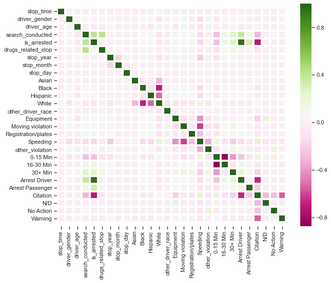

```python
print('Check the correlation between the features ( columns )')

plt.figure(figsize=(10,8))
ax = sns.heatmap(traffic_df.corr(), cmap="PiYG", linewidth=3)
# to fix the bug "first and last row cut in half of heatmap plot"
bottom, top = ax.get_ylim()
ax.set_ylim(bottom + 0.5, top - 0.5)
```

```python
# Observtation
print("There is Collinearity (> 0.5 or < -0.5) between several columns")
```

```
There is Collinearity (> 0.5 or < -0.5) between several columns
```

```python
print('Remove the collinearity:')

traffic_df = traffic_df[['stop_time', 'driver_gender', 'driver_age',
       'is_arrested', 'drugs_related_stop', 'stop_year', 'stop_month',
       'stop_day', 'Asian', 'Black', 'Hispanic', 'other_driver_race', 'Registration/plates', 'Speeding',
       'other_violation', '16-30 Min', '30+ Min', 'Arrest Passenger', 'Citation', 'N/D', 'No Action']]
```

```
Remove the collinearity:
```

```
(21.5, -0.5)
```

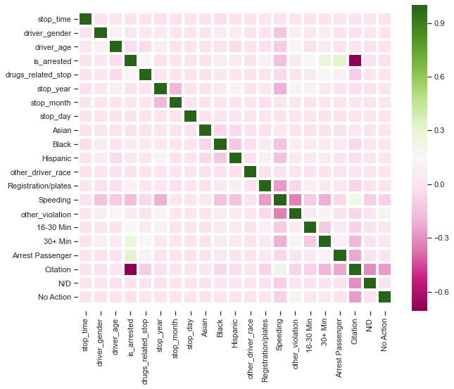

```python
plt.figure(figsize=(10,8))
ax = sns.heatmap(traffic_df.corr(),  cmap="PiYG", linewidth=3)
# to fix the bug "first and last row cut in half of heatmap plot"
bottom, top = ax.get_ylim()
ax.set_ylim(bottom + 0.5, top - 0.5)
```

### - Check the outliers

```
Check the outliner in age columns:
```

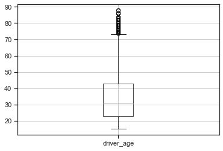

```python
print('Check the outliner in age columns: ')

traffic_df.boxplot(column=['driver_age'])
```

```python
print( 'Remove the outliers rows :')

Q1 = traffic_df['driver_age'].quantile(0.25)
Q3 = traffic_df['driver_age'].quantile(0.75)
IQR = Q3 - Q1    #IQR is interquartile range.

filter = (traffic_df['driver_age'] >= Q1 - 1.5 * IQR) & (traffic_df['driver_age'] <= Q3 + 1.5 *IQR)
print('The remain rows :', len(traffic_df.loc[filter] ))
```

```
Remove the outliers rows :
The remain rows : 49018
```

```python
print('Save the filtered data: \n')
traffic_df = traffic_df.loc[filter]
```

```
Save the filtered data:
```

```python
print("Check the statistical measures for each column: \n \n")
traffic_df.describe(include='all')
```

```
Check the statistical measures for each column:
```

|  | stop_time | driver_gender | driver_age | is_arrested | drugs_related_stop | stop_year | stop_month | stop_day | Asian | Black | ... | other_driver_race | Registration/plates | Speeding | other_violation | 16-30 Min | 30+ Min | Arrest Passenger | Citation | N/D | No Action |
| --- | --- | --- | --- | --- | --- | --- | --- | --- | --- | --- | --- | --- | --- | --- | --- | --- | --- | --- | --- | --- | --- |
| count | 49018.000000 | 49018.000000 | 49018.000000 | 49018.000000 | 49018.000000 | 49018.000000 | 49018.000000 | 49018.000000 | 49018.000000 | 49018.000000 | ... | 49018.000000 | 49018.000000 | 49018.000000 | 49018.000000 | 49018.000000 | 49018.000000 | 49018.000000 | 49018.000000 | 49018.000000 | 49018.000000 |
| mean | 12.073355 | 0.736321 | 34.046228 | 0.037517 | 0.008058 | 2008.032947 | 6.408503 | 15.591844 | 0.027786 | 0.133155 | ... | 0.002999 | 0.036721 | 0.650210 | 0.057836 | 0.198172 | 0.046289 | 0.004080 | 0.928230 | 0.007099 | 0.005304 |
| std | 6.530781 | 0.440632 | 12.561256 | 0.190026 | 0.089406 | 1.785906 | 3.451677 | 8.813939 | 0.164360 | 0.339746 | ... | 0.054681 | 0.188078 | 0.476908 | 0.233435 | 0.398627 | 0.210113 | 0.063746 | 0.258109 | 0.083959 | 0.072637 |
| min | 0.000000 | 0.000000 | 15.000000 | 0.000000 | 0.000000 | 2005.000000 | 1.000000 | 1.000000 | 0.000000 | 0.000000 | ... | 0.000000 | 0.000000 | 0.000000 | 0.000000 | 0.000000 | 0.000000 | 0.000000 | 0.000000 | 0.000000 | 0.000000 |
| 25% | 8.100000 | 0.000000 | 23.000000 | 0.000000 | 0.000000 | 2006.000000 | 3.000000 | 8.000000 | 0.000000 | 0.000000 | ... | 0.000000 | 0.000000 | 0.000000 | 0.000000 | 0.000000 | 0.000000 | 0.000000 | 1.000000 | 0.000000 | 0.000000 |
| 50% | 11.550000 | 1.000000 | 31.000000 | 0.000000 | 0.000000 | 2008.000000 | 6.000000 | 15.000000 | 0.000000 | 0.000000 | ... | 0.000000 | 0.000000 | 1.000000 | 0.000000 | 0.000000 | 0.000000 | 0.000000 | 1.000000 | 0.000000 | 0.000000 |
| 75% | 16.566667 | 1.000000 | 43.000000 | 0.000000 | 0.000000 | 2010.000000 | 9.000000 | 23.000000 | 0.000000 | 0.000000 | ... | 0.000000 | 0.000000 | 1.000000 | 0.000000 | 0.000000 | 0.000000 | 0.000000 | 1.000000 | 0.000000 | 0.000000 |
| max | 23.983333 | 1.000000 | 73.000000 | 1.000000 | 1.000000 | 2011.000000 | 12.000000 | 31.000000 | 1.000000 | 1.000000 | ... | 1.000000 | 1.000000 | 1.000000 | 1.000000 | 1.000000 | 1.000000 | 1.000000 | 1.000000 | 1.000000 | 1.000000 |

8 rows × 21 columns

### - Save the data after the preprocessing

```python
traffic_df.to_csv('./Data_before_and_after_preprocessing/traffic_violaions_after_preprocessing.csv', index=False)
```

### - Fix imbalanced data

```python
from imblearn.over_sampling import SMOTE
from imblearn.under_sampling import RandomUnderSampler
from sklearn.model_selection import train_test_split
from collections import Counter
```

```python
X = traffic_df.drop('is_arrested',axis = 1)
y = traffic_df['is_arrested']
```

```python
############################### Over Sampling #################################################

#Split train-test data
X_train_overSampling, X_test_overSampling, y_train_overSampling, y_test_overSampling = train_test_split(X,y,test_size=0.30)

# summarize class distribution
print("Before oversampling: ",Counter(y_train_overSampling))

# define oversampling strategy
SMOTE = SMOTE()

# fit and apply the transform
X_train_SMOTE, y_train_SMOTE = SMOTE.fit_resample(X_train_overSampling, y_train_overSampling)

# summarize class distribution
print("After oversampling: ",Counter(y_train_SMOTE))
```

```
Before oversampling:  Counter({0: 32998, 1: 1314})
After oversampling:  Counter({0: 32998, 1: 32998})
```

```python
print("Check the statistical measures for each column: \n \n")
X_train_SMOTE.describe(include='all')
```

```
Check the statistical measures for each column:
```

|  | stop_time | driver_gender | driver_age | drugs_related_stop | stop_year | stop_month | stop_day | Asian | Black | Hispanic | other_driver_race | Registration/plates | Speeding | other_violation | 16-30 Min | 30+ Min | Arrest Passenger | Citation | N/D | No Action |
| --- | --- | --- | --- | --- | --- | --- | --- | --- | --- | --- | --- | --- | --- | --- | --- | --- | --- | --- | --- | --- |
| count | 65996.000000 | 65996.000000 | 65996.000000 | 65996.000000 | 65996.000000 | 65996.000000 | 65996.000000 | 65996.000000 | 65996.000000 | 65996.000000 | 65996.000000 | 65996.000000 | 65996.000000 | 65996.000000 | 65996.000000 | 65996.000000 | 65996.000000 | 65996.000000 | 65996.000000 | 65996.000000 |
| mean | 12.011107 | 0.700967 | 32.886168 | 0.006606 | 2007.765698 | 6.261455 | 15.230544 | 0.014486 | 0.105203 | 0.050503 | 0.001621 | 0.029108 | 0.376720 | 0.039457 | 0.228984 | 0.083823 | 0.007940 | 0.482363 | 0.003667 | 0.002758 |
| std | 6.902741 | 0.457838 | 11.432439 | 0.081012 | 1.774285 | 3.433874 | 8.743076 | 0.119483 | 0.306818 | 0.218982 | 0.040233 | 0.168110 | 0.484567 | 0.194681 | 0.420182 | 0.277125 | 0.088752 | 0.499693 | 0.060444 | 0.052442 |
| min | 0.000000 | 0.000000 | 15.000000 | 0.000000 | 2005.000000 | 1.000000 | 1.000000 | 0.000000 | 0.000000 | 0.000000 | 0.000000 | 0.000000 | 0.000000 | 0.000000 | 0.000000 | 0.000000 | 0.000000 | 0.000000 | 0.000000 | 0.000000 |
| 25% | 7.816667 | 0.000000 | 23.506496 | 0.000000 | 2006.000000 | 3.000000 | 7.000000 | 0.000000 | 0.000000 | 0.000000 | 0.000000 | 0.000000 | 0.000000 | 0.000000 | 0.000000 | 0.000000 | 0.000000 | 0.000000 | 0.000000 | 0.000000 |
| 50% | 11.868131 | 1.000000 | 29.777888 | 0.000000 | 2008.000000 | 6.000000 | 15.000000 | 0.000000 | 0.000000 | 0.000000 | 0.000000 | 0.000000 | 0.000000 | 0.000000 | 0.000000 | 0.000000 | 0.000000 | 0.000000 | 0.000000 | 0.000000 |
| 75% | 17.066667 | 1.000000 | 41.000000 | 0.000000 | 2009.000000 | 9.000000 | 23.000000 | 0.000000 | 0.000000 | 0.000000 | 0.000000 | 0.000000 | 1.000000 | 0.000000 | 0.000000 | 0.000000 | 0.000000 | 1.000000 | 0.000000 | 0.000000 |
| max | 23.983333 | 1.000000 | 73.000000 | 1.000000 | 2011.000000 | 12.000000 | 31.000000 | 1.000000 | 1.000000 | 1.000000 | 1.000000 | 1.000000 | 1.000000 | 1.000000 | 1.000000 | 1.000000 | 1.000000 | 1.000000 | 1.000000 | 1.000000 |

```python
############################### Under Sampling #################################################

#Split train-test data
X_train_underSampling, X_test_underSampling, y_train_underSampling, y_test_underSampling = train_test_split(X,y,test_size=0.30)

# summarize class distribution
print("Before undersampling: ", Counter(y_train_underSampling))

# define undersampling strategy
undersample = RandomUnderSampler(sampling_strategy='majority')

# fit and apply the transform
X_train_under, y_train_under = undersample.fit_resample(X_train_underSampling, y_train_underSampling)

# summarize class distribution
print("After undersampling: ", Counter(y_train_under))
```

```
Before undersampling:  Counter({0: 33056, 1: 1256})
After undersampling:  Counter({0: 1256, 1: 1256})
```

```python
print("Check the statistical measures for each column: \n \n")
X_train_under.describe(include='all')
```

```
Check the statistical measures for each column:
```

|  | stop_time | driver_gender | driver_age | drugs_related_stop | stop_year | stop_month | stop_day | Asian | Black | Hispanic | other_driver_race | Registration/plates | Speeding | other_violation | 16-30 Min | 30+ Min | Arrest Passenger | Citation | N/D | No Action |
| --- | --- | --- | --- | --- | --- | --- | --- | --- | --- | --- | --- | --- | --- | --- | --- | --- | --- | --- | --- | --- |
| count | 2512.000000 | 2512.000000 | 2512.000000 | 2512.000000 | 2512.000000 | 2512.000000 | 2512.000000 | 2512.000000 | 2512.000000 | 2512.000000 | 2512.000000 | 2512.000000 | 2512.000000 | 2512.000000 | 2512.000000 | 2512.000000 | 2512.000000 | 2512.000000 | 2512.000000 | 2512.000000 |
| mean | 12.006973 | 0.773089 | 33.145303 | 0.037420 | 2007.994825 | 6.445064 | 15.505971 | 0.018312 | 0.183121 | 0.115844 | 0.003583 | 0.087182 | 0.461385 | 0.078025 | 0.331210 | 0.189092 | 0.060111 | 0.484475 | 0.001592 | 0.002787 |
| std | 6.944684 | 0.418918 | 11.558484 | 0.189827 | 1.865759 | 3.522834 | 8.779885 | 0.134104 | 0.386843 | 0.320101 | 0.059761 | 0.282157 | 0.498606 | 0.268265 | 0.470742 | 0.391660 | 0.237741 | 0.499858 | 0.039880 | 0.052725 |
| min | 0.000000 | 0.000000 | 15.000000 | 0.000000 | 2005.000000 | 1.000000 | 1.000000 | 0.000000 | 0.000000 | 0.000000 | 0.000000 | 0.000000 | 0.000000 | 0.000000 | 0.000000 | 0.000000 | 0.000000 | 0.000000 | 0.000000 | 0.000000 |
| 25% | 7.666667 | 1.000000 | 23.000000 | 0.000000 | 2006.000000 | 3.000000 | 8.000000 | 0.000000 | 0.000000 | 0.000000 | 0.000000 | 0.000000 | 0.000000 | 0.000000 | 0.000000 | 0.000000 | 0.000000 | 0.000000 | 0.000000 | 0.000000 |
| 50% | 12.000000 | 1.000000 | 30.000000 | 0.000000 | 2008.000000 | 6.000000 | 15.000000 | 0.000000 | 0.000000 | 0.000000 | 0.000000 | 0.000000 | 0.000000 | 0.000000 | 0.000000 | 0.000000 | 0.000000 | 0.000000 | 0.000000 | 0.000000 |
| 75% | 16.983333 | 1.000000 | 41.000000 | 0.000000 | 2010.000000 | 10.000000 | 23.000000 | 0.000000 | 0.000000 | 0.000000 | 0.000000 | 0.000000 | 1.000000 | 0.000000 | 1.000000 | 0.000000 | 0.000000 | 1.000000 | 0.000000 | 0.000000 |
| max | 23.983333 | 1.000000 | 73.000000 | 1.000000 | 2011.000000 | 12.000000 | 31.000000 | 1.000000 | 1.000000 | 1.000000 | 1.000000 | 1.000000 | 1.000000 | 1.000000 | 1.000000 | 1.000000 | 1.000000 | 1.000000 | 1.000000 | 1.000000 |

# Modeling

```python
# import models
from sklearn.preprocessing import StandardScaler
from sklearn.metrics import mean_absolute_error, accuracy_score, confusion_matrix, precision_score, precision_recall_curve, PrecisionRecallDisplay
from sklearn.linear_model import LogisticRegression
from sklearn import svm
from sklearn.metrics import classification_report, confusion_matrix
```

### - Fits the model on OverSampled data:

```python
# Standardize
std_scale = StandardScaler().fit(X_train_SMOTE)
X_train_std_over = std_scale.transform(X_train_SMOTE)
X_test_std_over = std_scale.transform(X_test_underSampling)
```

### - SVM function

```python
def SVM_hyperparameterOptimization( X_train_std, y_train,X_test, y_test, text='over Sampling' ):

    """

    X_train_std: X train dataset Standardized
    y_train: y train dataset (target)
    X_test: X test dataset
    y_test: y test dataset (target)
    text: imbalanced data technique

    """

    # kernal: Specifies the kernel type to be used in the algorithm.
    kernels = ['linear',  'sigmoid']

    #C: Regularization parameter. The strength of the regularization is inversely proportional
    #to C. Must be strictly positive. The penalty is a squared l2 penalty.
    C = [1.0, 1.5]


    # save the acc result
    acc = []


    # for each kernal, loop over the hyperparameter and fit the model
    for kernel in kernels:

        acc_kernel  = []

        for i in range(len(C)):

            # init the model with C and epsilon
            svm_model= svm.SVC(kernel=kernel, C=C[i], probability=True)

            # fit SVM
            svm_model.fit(X_train_std, y_train)


            # predict
            predict_svm = svm_model.predict(X_test)

           # test the model accuracy
            mae_svm = mean_absolute_error(y_test, predict_svm)
            accuracy = accuracy_score(y_test, predict_svm)


            # print:
            print(' SVM with kernel {0} and {1} technique, C= {2:0.3f}  MSE: {3:0.3f}'.format(kernel, text, C[i],  mae_svm))
            print(' SVM with kernel {0} and {1} technique, C= {2:0.3f}  Acc: {3:0.3f}'.format(kernel, text, C[i],  accuracy))


            precision = precision_score(y_test, predict_svm)
            print('SVM with kernel {0} and {1} technique, C= {2:0.3f} PPTV: {3:0.3f}'.format(kernel, text, C[i], precision))

            TP, FP, TN, FN = confusion_matrix(y_test, predict_svm).ravel()
            print('TP: {0:0.3f} FP: {1:0.3f} TN: {2:0.3f}  FN: {3:0.3f}'.format(TP, FP, TN, FN))

            if (TN+FN) == 0:
                FN= 1
            NPV = TN/(TN+FN)
            print('SVM with kernel {0} and {1} technique, C= {2:0.3f} NPV: {3:0.3f}'.format(kernel, text, C[i], NPV))

            recall = TP/(TP+FN)
            print('SVM with kernel {0} and {1} technique, C= {2:0.3f} Recall: {3:0.3f}'.format(kernel, text, C[i], recall))

            specificity = TN / (TN+FP)
            print('SVM with kernel {0} and {1} technique, C= {2:0.3f} Specificity: {3:0.3f}'.format(kernel, text, C[i], specificity))


            F1 = 2* ((precision*recall)/(precision+recall))
            print('SVM with kernel {0} and {1} technique, C= {2:0.3f} F1: {3:0.3f}'.format(kernel, text, C[i], F1))



            print('-----------------------------------------------------------------------------------------------------------------------------------')

            acc_kernel.append(mae_svm)

        # append the acc for visualize
        acc.append(acc_kernel)

    df = pd.DataFrame(acc,
                     index=kernels,
                     columns=pd.Index([ 'MSE with C=1.0', 'MSE with C=1.5'],
                     name='Kernels'))

    print(df)
    df.plot(kind='bar',figsize=(20,8))

    ax = plt.gca()
    pos = []

    for bar in ax.patches:
        pos.append(bar.get_x()+bar.get_width()/2.)
        ax.annotate(str(bar.get_height()), (bar.get_x() * 1.005, bar.get_height() * 1.005))



    ax.set_xticks(pos,minor=True)
    lab = []
    for i in range(len(pos)):
        l = df.values[i//len(df.index.values)][0]
        lab.append(l)



    plt.title("SVM Hyperparameter Optimization")
    plt.show()
```

### - SVM with OverSampled data

```
 SVM with kernel linear and over Sampling technique, C= 1.000  MSE: 0.036
 SVM with kernel linear and over Sampling technique, C= 1.000  Acc: 0.964
SVM with kernel linear and over Sampling technique, C= 1.000 PPTV: 0.000
TP: 14181.000 FP: 0.000 TN: 525.000  FN: 0.000
SVM with kernel linear and over Sampling technique, C= 1.000 NPV: 1.000
SVM with kernel linear and over Sampling technique, C= 1.000 Recall: 1.000
SVM with kernel linear and over Sampling technique, C= 1.000 Specificity: 1.000
SVM with kernel linear and over Sampling technique, C= 1.000 F1: 0.000
-----------------------------------------------------------------------------------------------------------------------------------
 SVM with kernel linear and over Sampling technique, C= 1.500  MSE: 0.023
 SVM with kernel linear and over Sampling technique, C= 1.500  Acc: 0.977
SVM with kernel linear and over Sampling technique, C= 1.500 PPTV: 0.613
TP: 13850.000 FP: 331.000 TN: 0.000  FN: 525.000
SVM with kernel linear and over Sampling technique, C= 1.500 NPV: 0.000
SVM with kernel linear and over Sampling technique, C= 1.500 Recall: 0.963
SVM with kernel linear and over Sampling technique, C= 1.500 Specificity: 0.000
SVM with kernel linear and over Sampling technique, C= 1.500 F1: 0.750
-----------------------------------------------------------------------------------------------------------------------------------
 SVM with kernel sigmoid and over Sampling technique, C= 1.000  MSE: 0.036
 SVM with kernel sigmoid and over Sampling technique, C= 1.000  Acc: 0.964
SVM with kernel sigmoid and over Sampling technique, C= 1.000 PPTV: 0.000
TP: 14181.000 FP: 0.000 TN: 525.000  FN: 0.000
SVM with kernel sigmoid and over Sampling technique, C= 1.000 NPV: 1.000
SVM with kernel sigmoid and over Sampling technique, C= 1.000 Recall: 1.000
SVM with kernel sigmoid and over Sampling technique, C= 1.000 Specificity: 1.000
SVM with kernel sigmoid and over Sampling technique, C= 1.000 F1: 0.000
-----------------------------------------------------------------------------------------------------------------------------------
 SVM with kernel sigmoid and over Sampling technique, C= 1.500  MSE: 0.036
 SVM with kernel sigmoid and over Sampling technique, C= 1.500  Acc: 0.964
SVM with kernel sigmoid and over Sampling technique, C= 1.500 PPTV: 0.000
TP: 14181.000 FP: 0.000 TN: 525.000  FN: 0.000
SVM with kernel sigmoid and over Sampling technique, C= 1.500 NPV: 1.000
SVM with kernel sigmoid and over Sampling technique, C= 1.500 Recall: 1.000
SVM with kernel sigmoid and over Sampling technique, C= 1.500 Specificity: 1.000
SVM with kernel sigmoid and over Sampling technique, C= 1.500 F1: 0.000
-----------------------------------------------------------------------------------------------------------------------------------
Kernels  MSE with C=1.0  MSE with C=1.5
linear           0.0357        0.022508
sigmoid          0.0357        0.035700
```

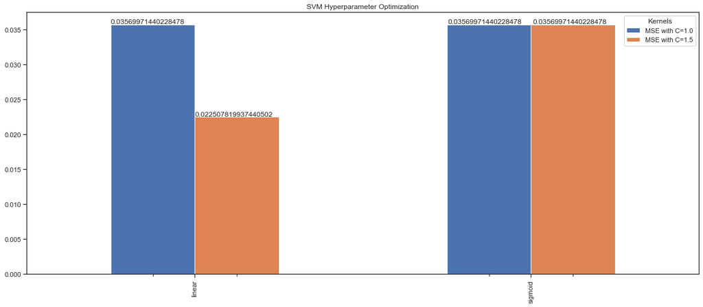

```python
# SVM hyperparameter Optimization
SVM_hyperparameterOptimization( X_train_std_over, y_train_SMOTE, X_test_overSampling, y_test_overSampling )
```

### 2. Logistic Regression function

```python
def LR_hyperparameterOptimization( X_train_std, y_train, X_test, y_test, text='over Sampling' ):

    """

    X_train_std: X train dataset Standardized
    y_train: y train dataset (target)
    X_test: X test dataset
    y_test: y test dataset (target)
    text: imbalanced data technique

    """

    # solver: Specifies the kernel type to be used in the algorithm.
    solvers = ['newton-cg', 'lbfgs', 'liblinear']


    acc = []


    # for each solver, loop over the hyperparameter and fit the model
    for solver in solvers:


        # init the model with diffrernt solver
        LogisticRegression_model = LogisticRegression(solver=solver, random_state=42)

        # fit SVM
        LogisticRegression_model.fit(X_train_std, y_train)

        # predict
        predict_lr = LogisticRegression_model.predict(X_test)

         # test the model accuracy
        mae_LAR = mean_absolute_error(y_test, predict_lr)
        accuracy = accuracy_score(y_test, predict_lr)

        # print
        print(' Logistic Regression with {0} and solver {1}, MSE: {2:0.3f}'.format(text, solver, mae_LAR))
        print(' Logistic Regression with {0} and solver {1}, accuracy: {2:0.3f}'.format(text, solver, accuracy))


        precision = precision_score(y_test, predict_lr)
        print('SVM with kernel {0} and {1} technique, C= {2:0.3f} PPTV: {2:0.3f}'.format(text, solver, precision))

        TP, FP, TN, FN = confusion_matrix(y_test, predict_lr).ravel()
        print('TP: {0:0.3f} FP: {1:0.3f} TN: {2:0.3f}  FN: {3:0.3f}'.format(TP, FP, TN, FN))

        if (TN+FN) == 0:
            FN= 1
        NPV = TN/(TN+FN)
        print('Logistic Regression with {0} and solver {1} NPV: {2:0.3f}'.format(text, solver, NPV))

        recall = TP/(TP+FN)
        print('Logistic Regression with {0} and solver {1} Recall: {2:0.3f}'.format(text, solver, recall))

        specificity = TN / (TN+FP)
        print('Logistic Regression with {0} and solver {1}Specificity: {2:0.3f}'.format(text, solver, specificity))


        F1 = 2* ((precision*recall)/(precision+recall))
        print('Logistic Regression with {0} and solver {1} F1: {2:0.3f}'.format(text, solver, F1))

        print('-----------------------------------------------------------------------------------------------------------------------------------')



        # append the acc for visualize
        acc.append(mae_LAR)


    df = pd.DataFrame(acc,
                     index=solvers,
                     columns=pd.Index([ 'acc']))


    df.plot(kind='bar',figsize=(20,8))

    ax = plt.gca()
    pos = []

    for bar in ax.patches:
        pos.append(bar.get_x()+bar.get_width()/2.)
        ax.annotate(str(bar.get_height()), (bar.get_x() * 1.005, bar.get_height() * 1.005))



    ax.set_xticks(pos,minor=True)
    lab = []
    for i in range(len(pos)):
        l = df.values[i//len(df.index.values)][0]
        lab.append(l)



    plt.title("SVM Hyperparameter Optimization")
    plt.show()
```

### - Logistic Regression with OverSampled data

```
 Logistic Regression with over Sampling and solver newton-cg, MSE: 0.036
 Logistic Regression with over Sampling and solver newton-cg, accuracy: 0.964
SVM with kernel over Sampling and newton-cg technique, C= 0.000 PPTV: 0.000
TP: 14181.000 FP: 0.000 TN: 525.000  FN: 0.000
Logistic Regression with over Sampling and solver newton-cg NPV: 1.000
Logistic Regression with over Sampling and solver newton-cg Recall: 1.000
Logistic Regression with over Sampling and solver newton-cgSpecificity: 1.000
Logistic Regression with over Sampling and solver newton-cg F1: 0.000
-----------------------------------------------------------------------------------------------------------------------------------
 Logistic Regression with over Sampling and solver lbfgs, MSE: 0.036
 Logistic Regression with over Sampling and solver lbfgs, accuracy: 0.964
SVM with kernel over Sampling and lbfgs technique, C= 0.000 PPTV: 0.000
TP: 14181.000 FP: 0.000 TN: 525.000  FN: 0.000
Logistic Regression with over Sampling and solver lbfgs NPV: 1.000
Logistic Regression with over Sampling and solver lbfgs Recall: 1.000
Logistic Regression with over Sampling and solver lbfgsSpecificity: 1.000
Logistic Regression with over Sampling and solver lbfgs F1: 0.000
-----------------------------------------------------------------------------------------------------------------------------------
 Logistic Regression with over Sampling and solver liblinear, MSE: 0.036
 Logistic Regression with over Sampling and solver liblinear, accuracy: 0.964
SVM with kernel over Sampling and liblinear technique, C= 0.000 PPTV: 0.000
TP: 14181.000 FP: 0.000 TN: 525.000  FN: 0.000
Logistic Regression with over Sampling and solver liblinear NPV: 1.000
Logistic Regression with over Sampling and solver liblinear Recall: 1.000
Logistic Regression with over Sampling and solver liblinearSpecificity: 1.000
Logistic Regression with over Sampling and solver liblinear F1: 0.000
-----------------------------------------------------------------------------------------------------------------------------------
```

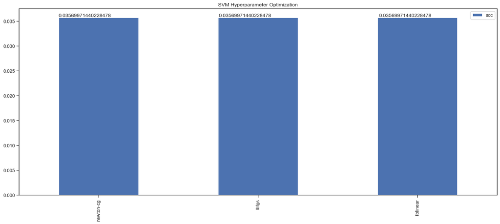

```python
# init the model
LR_hyperparameterOptimization( X_train_std_over, y_train_SMOTE, X_test_overSampling, y_test_overSampling )
```

## - Fits the model on UnderSampled data:

```python
# Standardize
std_scale = StandardScaler().fit(X_train_under)
X_train_std = std_scale.transform(X_train_under)
X_test_std  = std_scale.transform(X_test_underSampling)
```

### 1. SVM with under Sampled data

```
 SVM with kernel linear and Under Sampled data technique, C= 1.000  MSE: 0.040
 SVM with kernel linear and Under Sampled data technique, C= 1.000  Acc: 0.960
SVM with kernel linear and Under Sampled data technique, C= 1.000 PPTV: 0.000
TP: 14123.000 FP: 0.000 TN: 583.000  FN: 0.000
SVM with kernel linear and Under Sampled data technique, C= 1.000 NPV: 1.000
SVM with kernel linear and Under Sampled data technique, C= 1.000 Recall: 1.000
SVM with kernel linear and Under Sampled data technique, C= 1.000 Specificity: 1.000
SVM with kernel linear and Under Sampled data technique, C= 1.000 F1: 0.000
-----------------------------------------------------------------------------------------------------------------------------------
 SVM with kernel linear and Under Sampled data technique, C= 1.500  MSE: 0.040
 SVM with kernel linear and Under Sampled data technique, C= 1.500  Acc: 0.960
SVM with kernel linear and Under Sampled data technique, C= 1.500 PPTV: 0.000
TP: 14123.000 FP: 0.000 TN: 583.000  FN: 0.000
SVM with kernel linear and Under Sampled data technique, C= 1.500 NPV: 1.000
SVM with kernel linear and Under Sampled data technique, C= 1.500 Recall: 1.000
SVM with kernel linear and Under Sampled data technique, C= 1.500 Specificity: 1.000
SVM with kernel linear and Under Sampled data technique, C= 1.500 F1: 0.000
-----------------------------------------------------------------------------------------------------------------------------------
 SVM with kernel sigmoid and Under Sampled data technique, C= 1.000  MSE: 0.960
 SVM with kernel sigmoid and Under Sampled data technique, C= 1.000  Acc: 0.040
SVM with kernel sigmoid and Under Sampled data technique, C= 1.000 PPTV: 0.040
TP: 0.000 FP: 14123.000 TN: 0.000  FN: 583.000
SVM with kernel sigmoid and Under Sampled data technique, C= 1.000 NPV: 0.000
SVM with kernel sigmoid and Under Sampled data technique, C= 1.000 Recall: 0.000
SVM with kernel sigmoid and Under Sampled data technique, C= 1.000 Specificity: 0.000
SVM with kernel sigmoid and Under Sampled data technique, C= 1.000 F1: 0.000
-----------------------------------------------------------------------------------------------------------------------------------
 SVM with kernel sigmoid and Under Sampled data technique, C= 1.500  MSE: 0.641
 SVM with kernel sigmoid and Under Sampled data technique, C= 1.500  Acc: 0.359
SVM with kernel sigmoid and Under Sampled data technique, C= 1.500 PPTV: 0.040
TP: 4892.000 FP: 9231.000 TN: 197.000  FN: 386.000
SVM with kernel sigmoid and Under Sampled data technique, C= 1.500 NPV: 0.338
SVM with kernel sigmoid and Under Sampled data technique, C= 1.500 Recall: 0.927
SVM with kernel sigmoid and Under Sampled data technique, C= 1.500 Specificity: 0.021
SVM with kernel sigmoid and Under Sampled data technique, C= 1.500 F1: 0.077
-----------------------------------------------------------------------------------------------------------------------------------
Kernels  MSE with C=1.0  MSE with C=1.5
linear         0.039644        0.039644
sigmoid        0.960356        0.641099
```

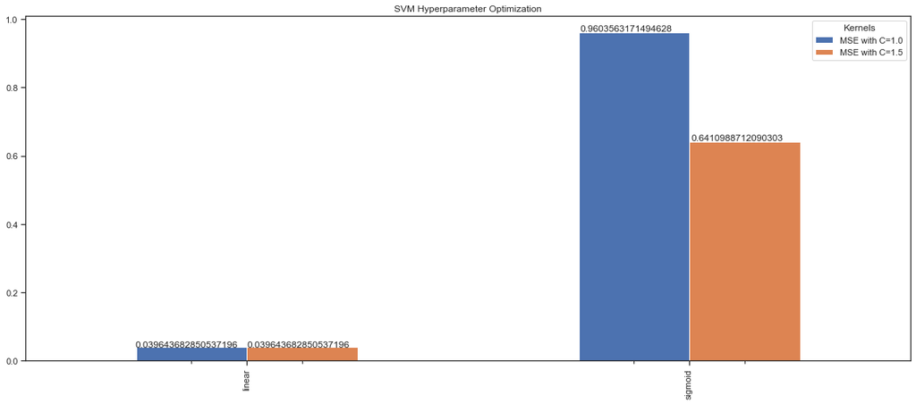

```python
# fit SVM

SVM_hyperparameterOptimization( X_train_std, y_train_under, X_test_underSampling, y_test_underSampling, 'Under Sampled data' )
```

### 2. Logistic Regression with under Sampled data

```
 Logistic Regression with Under Sampled data and solver newton-cg, MSE: 0.040
 Logistic Regression with Under Sampled data and solver newton-cg, accuracy: 0.960
SVM with kernel Under Sampled data and newton-cg technique, C= 0.000 PPTV: 0.000
TP: 14123.000 FP: 0.000 TN: 583.000  FN: 0.000
Logistic Regression with Under Sampled data and solver newton-cg NPV: 1.000
Logistic Regression with Under Sampled data and solver newton-cg Recall: 1.000
Logistic Regression with Under Sampled data and solver newton-cgSpecificity: 1.000
Logistic Regression with Under Sampled data and solver newton-cg F1: 0.000
-----------------------------------------------------------------------------------------------------------------------------------
 Logistic Regression with Under Sampled data and solver lbfgs, MSE: 0.040
 Logistic Regression with Under Sampled data and solver lbfgs, accuracy: 0.960
SVM with kernel Under Sampled data and lbfgs technique, C= 0.000 PPTV: 0.000
TP: 14123.000 FP: 0.000 TN: 583.000  FN: 0.000
Logistic Regression with Under Sampled data and solver lbfgs NPV: 1.000
Logistic Regression with Under Sampled data and solver lbfgs Recall: 1.000
Logistic Regression with Under Sampled data and solver lbfgsSpecificity: 1.000
Logistic Regression with Under Sampled data and solver lbfgs F1: 0.000
-----------------------------------------------------------------------------------------------------------------------------------
 Logistic Regression with Under Sampled data and solver liblinear, MSE: 0.040
 Logistic Regression with Under Sampled data and solver liblinear, accuracy: 0.960
SVM with kernel Under Sampled data and liblinear technique, C= 0.000 PPTV: 0.000
TP: 14123.000 FP: 0.000 TN: 583.000  FN: 0.000
Logistic Regression with Under Sampled data and solver liblinear NPV: 1.000
Logistic Regression with Under Sampled data and solver liblinear Recall: 1.000
Logistic Regression with Under Sampled data and solver liblinearSpecificity: 1.000
Logistic Regression with Under Sampled data and solver liblinear F1: 0.000
-----------------------------------------------------------------------------------------------------------------------------------
```

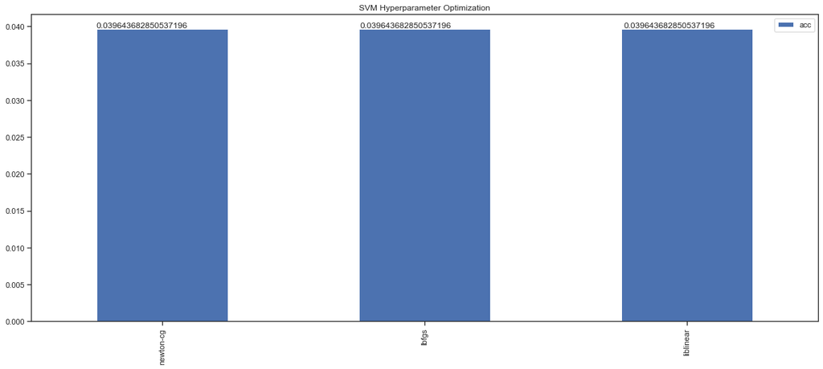

```python
# init the model
LR_hyperparameterOptimization(X_train_std, y_train_under, X_test_underSampling, y_test_underSampling, 'Under Sampled data')
```

# Communicating Results

### Based on pervious evaluation, SVM with Kernel = linear and C= 1.5, with over sampling technique to balance the target classes distribution performed better than Logistic Regression. The difference between the two algorithm is not significant. I believe that SVM preformed better Logistic Regression because that my data is linearly separable.